# Object detection as in SSD (basic principles)

```r
library(tensorflow)
library(keras)
library(rjson)
library(magick)
library(purrr)
library(tibble)
library(tidyr)
library(dplyr)
library(ggplot2)
library(stringr)
library(abind)

use_session_with_seed(7777, disable_gpu = FALSE, disable_parallel_cpu = FALSE)
```

```
2018-12-17 20:39:08.314576: I tensorflow/core/platform/cpu_feature_guard.cc:141] Your CPU supports instructions that this TensorFlow binary was not compiled to use: AVX2 FMA
Set session seed to 7777
```

```r
data_dir <- config::get("data_dir")
```

```
incomplete final line found on '/home/key/code/rstudio/conf_tensorflow_training_day2/2_object_detection/config.yml'
```

```r
img_dir <- file.path(data_dir, "VOCdevkit/VOC2007/JPEGImages")
```

```r
annot_file <- file.path(data_dir, "pascal_train2007.json")
```

## Preprocessing

```r
load_and_preprocess_image <- function(image_name, target_height, target_width) {
  img_array <- image_load(
    file.path(img_dir, image_name),
    target_size = c(target_height, target_width)
    ) %>%
    image_to_array() %>%
    imagenet_preprocess_input()
  dim(img_array) <- c(1, dim(img_array))
  img_array
}
```

```r
annotations <- fromJSON(file = annot_file)
str(annotations, max.level = 1)
```

```
List of 4
 $ images     :List of 2501
 $ type       : chr "instances"
 $ annotations:List of 7844
 $ categories :List of 20
```

```r
imageinfo <- annotations$images %>% {
  tibble(
    id = map_dbl(., "id"),
    file_name = map_chr(., "file_name"),
    image_height = map_dbl(., "height"),
    image_width = map_dbl(., "width")
  )
}
imageinfo
```

| id | file_name | image_height | image_width |
| --- | --- | --- | --- |
| 12 | 000012.jpg | 333 | 500 |
| 17 | 000017.jpg | 364 | 480 |
| 23 | 000023.jpg | 500 | 334 |
| 26 | 000026.jpg | 333 | 500 |
| 32 | 000032.jpg | 281 | 500 |
| 33 | 000033.jpg | 366 | 500 |
| 34 | 000034.jpg | 500 | 360 |
| 35 | 000035.jpg | 375 | 500 |
| 36 | 000036.jpg | 500 | 332 |
| 42 | 000042.jpg | 335 | 500 |

[output cut: 990 more lines]

```r
boxinfo <- annotations$annotations %>% {
  tibble(
    image_id = map_dbl(., "image_id"),
    category_id = map_dbl(., "category_id"),
    bbox = map(., "bbox")
  )
}
boxinfo
```

| image_id | category_id | bbox |
| --- | --- | --- |
| 12 | 7 |  |
| 17 | 15 |  |
| 17 | 13 |  |
| 23 | 2 |  |
| 23 | 2 |  |
| 23 | 2 |  |
| 23 | 15 |  |
| 23 | 15 |  |
| 23 | 15 |  |
| 26 | 7 |  |

[output cut: 990 more lines]

```r
boxinfo <- boxinfo %>%
  mutate(bbox = unlist(map(.$bbox, function(x) paste(x, collapse = " "))))
boxinfo <- boxinfo %>%
  separate(bbox, into = c("x_left", "y_top", "bbox_width", "bbox_height"))
boxinfo <- boxinfo %>% mutate_all(as.numeric)
boxinfo
```

| image_id | category_id | x_left | y_top | bbox_width | bbox_height |
| --- | --- | --- | --- | --- | --- |
| 12 | 7 | 155 | 96 | 196 | 174 |
| 17 | 15 | 184 | 61 | 95 | 138 |
| 17 | 13 | 89 | 77 | 314 | 259 |
| 23 | 2 | 8 | 229 | 237 | 271 |
| 23 | 2 | 229 | 219 | 105 | 281 |
| 23 | 2 | 1 | 177 | 89 | 323 |
| 23 | 15 | 1 | 0 | 116 | 369 |
| 23 | 15 | 2 | 1 | 241 | 461 |
| 23 | 15 | 224 | 0 | 110 | 486 |
| 26 | 7 | 89 | 124 | 248 | 88 |

[output cut: 990 more lines]

```r
boxinfo <- boxinfo %>%
  mutate(y_bottom = y_top + bbox_height - 1, x_right = x_left + bbox_width - 1)
boxinfo
```

| image_id | category_id | x_left | y_top | bbox_width | bbox_height | y_bottom | x_right |
| --- | --- | --- | --- | --- | --- | --- | --- |
| 12 | 7 | 155 | 96 | 196 | 174 | 269 | 350 |
| 17 | 15 | 184 | 61 | 95 | 138 | 198 | 278 |
| 17 | 13 | 89 | 77 | 314 | 259 | 335 | 402 |
| 23 | 2 | 8 | 229 | 237 | 271 | 499 | 244 |
| 23 | 2 | 229 | 219 | 105 | 281 | 499 | 333 |
| 23 | 2 | 1 | 177 | 89 | 323 | 499 | 89 |
| 23 | 15 | 1 | 0 | 116 | 369 | 368 | 116 |
| 23 | 15 | 2 | 1 | 241 | 461 | 461 | 242 |
| 23 | 15 | 224 | 0 | 110 | 486 | 485 | 333 |
| 26 | 7 | 89 | 124 | 248 | 88 | 211 | 336 |

[output cut: 990 more lines]

```r
catinfo <- annotations$categories %>%  {
  tibble(id = map_dbl(., "id"), name = map_chr(., "name"))
}
catinfo
```

| id | name |
| --- | --- |
| 1 | aeroplane |
| 2 | bicycle |
| 3 | bird |
| 4 | boat |
| 5 | bottle |
| 6 | bus |
| 7 | car |
| 8 | cat |
| 9 | chair |
| 10 | cow |

[output cut: 10 more lines]

```r
class_names <- c(catinfo$name, "bg")
n_classes <- 20
```

```r
imageinfo <- imageinfo %>%
  inner_join(boxinfo, by = c("id" = "image_id")) %>%
  inner_join(catinfo, by = c("category_id" = "id"))
imageinfo
```

| id | file_name | image_height | image_width | category_id | x_left | y_top | bbox_width | bbox_height | y_bottom | x_right | name |
| --- | --- | --- | --- | --- | --- | --- | --- | --- | --- | --- | --- |
| 12 | 000012.jpg | 333 | 500 | 7 | 155 | 96 | 196 | 174 | 269 | 350 | car |
| 17 | 000017.jpg | 364 | 480 | 15 | 184 | 61 | 95 | 138 | 198 | 278 | person |
| 17 | 000017.jpg | 364 | 480 | 13 | 89 | 77 | 314 | 259 | 335 | 402 | horse |
| 23 | 000023.jpg | 500 | 334 | 2 | 8 | 229 | 237 | 271 | 499 | 244 | bicycle |
| 23 | 000023.jpg | 500 | 334 | 2 | 229 | 219 | 105 | 281 | 499 | 333 | bicycle |
| 23 | 000023.jpg | 500 | 334 | 2 | 1 | 177 | 89 | 323 | 499 | 89 | bicycle |
| 23 | 000023.jpg | 500 | 334 | 15 | 1 | 0 | 116 | 369 | 368 | 116 | person |
| 23 | 000023.jpg | 500 | 334 | 15 | 2 | 1 | 241 | 461 | 461 | 242 | person |
| 23 | 000023.jpg | 500 | 334 | 15 | 224 | 0 | 110 | 486 | 485 | 333 | person |
| 26 | 000026.jpg | 333 | 500 | 7 | 89 | 124 | 248 | 88 | 211 | 336 | car |

[output cut: 990 more lines]

```r
target_height <- 224
target_width <- 224

imageinfo <- imageinfo %>% mutate(
  x_left_scaled = (x_left / image_width * target_width) %>% round(),
  x_right_scaled = (x_right / image_width * target_width) %>% round(),
  y_top_scaled = (y_top / image_height * target_height) %>% round(),
  y_bottom_scaled = (y_bottom / image_height * target_height) %>% round(),
  bbox_width_scaled =  (bbox_width / image_width * target_width) %>% round(),
  bbox_height_scaled = (bbox_height / image_height * target_height) %>% round()
)
imageinfo
```

| id | file_name | image_height | image_width | category_id | x_left | y_top | bbox_width | bbox_height | y_bottom | x_right | name | x_left_scaled | x_right_scaled | y_top_scaled | y_bottom_scaled | bbox_width_scaled | bbox_height_scaled |
| --- | --- | --- | --- | --- | --- | --- | --- | --- | --- | --- | --- | --- | --- | --- | --- | --- | --- |
| 12 | 000012.jpg | 333 | 500 | 7 | 155 | 96 | 196 | 174 | 269 | 350 | car | 69 | 157 | 65 | 181 | 88 | 117 |
| 17 | 000017.jpg | 364 | 480 | 15 | 184 | 61 | 95 | 138 | 198 | 278 | person | 86 | 130 | 38 | 122 | 44 | 85 |
| 17 | 000017.jpg | 364 | 480 | 13 | 89 | 77 | 314 | 259 | 335 | 402 | horse | 42 | 188 | 47 | 206 | 147 | 159 |
| 23 | 000023.jpg | 500 | 334 | 2 | 8 | 229 | 237 | 271 | 499 | 244 | bicycle | 5 | 164 | 103 | 224 | 159 | 121 |
| 23 | 000023.jpg | 500 | 334 | 2 | 229 | 219 | 105 | 281 | 499 | 333 | bicycle | 154 | 223 | 98 | 224 | 70 | 126 |
| 23 | 000023.jpg | 500 | 334 | 2 | 1 | 177 | 89 | 323 | 499 | 89 | bicycle | 1 | 60 | 79 | 224 | 60 | 145 |
| 23 | 000023.jpg | 500 | 334 | 15 | 1 | 0 | 116 | 369 | 368 | 116 | person | 1 | 78 | 0 | 165 | 78 | 165 |
| 23 | 000023.jpg | 500 | 334 | 15 | 2 | 1 | 241 | 461 | 461 | 242 | person | 1 | 162 | 0 | 207 | 162 | 207 |
| 23 | 000023.jpg | 500 | 334 | 15 | 224 | 0 | 110 | 486 | 485 | 333 | person | 150 | 223 | 0 | 217 | 74 | 218 |
| 26 | 000026.jpg | 333 | 500 | 7 | 89 | 124 | 248 | 88 | 211 | 336 | car | 40 | 151 | 83 | 142 | 111 | 59 |

[output cut: 990 more lines]

```r
imageinfo4ssd <- imageinfo %>%
  select(category_id,
         file_name,
         name,
         x_left,
         y_top,
         x_right,
         y_bottom,
         ends_with("scaled"))
```

```r
imageinfo4ssd <- imageinfo4ssd %>%
  group_by(file_name) %>%
  summarise(
    categories = toString(category_id),
    name = toString(name),
    xl = toString(x_left_scaled),
    yt = toString(y_top_scaled),
    xr = toString(x_right_scaled),
    yb = toString(y_bottom_scaled),
    xl_orig = toString(x_left),
    yt_orig = toString(y_top),
    xr_orig = toString(x_right),
    yb_orig = toString(y_bottom),
    cnt = n()
  )

imageinfo4ssd
```

| file_name | categories | name | xl | yt | xr | yb | xl_orig | yt_orig | xr_orig | yb_orig | cnt |
| --- | --- | --- | --- | --- | --- | --- | --- | --- | --- | --- | --- |
| 000012.jpg | 7 | car | 69 | 65 | 157 | 181 | 155 | 96 | 350 | 269 | 1 |
| 000017.jpg | 15, 13 | person, horse | 86, 42 | 38, 47 | 130, 188 | 122, 206 | 184, 89 | 61, 77 | 278, 402 | 198, 335 | 2 |
| 000023.jpg | 2, 2, 2, 15, 15, 15 | bicycle, bicycle, bicycle, person, person, person | 5, 154, 1, 1, 1, 150 | 103, 98, 79, 0, 0, 0 | 164, 223, 60, 78, 162, 223 | 224, 224, 224, 165, 207, 217 | 8, 229, 1, 1, 2, 224 | 229, 219, 177, 0, 1, 0 | 244, 333, 89, 116, 242, 333 | 499, 499, 499, 368, 461, 485 | 6 |
| 000026.jpg | 7 | car | 40 | 83 | 151 | 142 | 89 | 124 | 336 | 211 | 1 |
| 000032.jpg | 1, 1, 15, 15 | aeroplane, aeroplane, person, person | 46, 59, 87, 11 | 61, 69, 143, 150 | 168, 88, 95, 19 | 145, 97, 182, 189 | 103, 132, 194, 25 | 77, 87, 179, 188 | 374, 196, 212, 43 | 182, 122, 228, 237 | 4 |
| 000033.jpg | 1, 1, 1 | aeroplane, aeroplane, aeroplane | 4, 188, 145 | 65, 122, 114 | 223, 215, 184 | 160, 138, 136 | 8, 420, 324 | 106, 199, 187 | 498, 481, 410 | 262, 225, 222 | 3 |
| 000034.jpg | 19, 19 | train, train | 72, 87 | 74, 68 | 223, 207 | 179, 102 | 115, 140 | 166, 152 | 359, 332 | 399, 228 | 2 |
| 000035.jpg | 15, 15, 15, 11 | person, person, person, diningtable | 0, 97, 209, 1 | 57, 58, 116, 181 | 85, 208, 224, 224 | 215, 189, 189, 223 | 0, 217, 467, 2 | 95, 97, 194, 303 | 190, 464, 499, 499 | 360, 317, 316, 374 | 4 |
| 000036.jpg | 12 | dog | 18 | 35 | 215 | 154 | 26 | 78 | 318 | 343 | 1 |
| 000042.jpg | 19, 19 | train, train | 117, 0 | 21, 23 | 224, 105 | 197, 199 | 262, 0 | 31, 35 | 499, 234 | 294, 298 | 2 |

[output cut: 990 more lines]

# More anchor boxes

We create anchor boxes as combinations of

- different scales:

```r
anchor_zooms <- c(0.7, 1, 1.3)
anchor_zooms
```

```
[1] 0.7 1.0 1.3
```

- and different aspect ratios:

```r
anchor_ratios <- matrix(c(1, 1, 1, 0.5, 0.5, 1), ncol = 2, byrow = TRUE)
anchor_ratios
```

```
     [,1] [,2]
[1,]  1.0  1.0
[2,]  1.0  0.5
[3,]  0.5  1.0
```

In this example, we have nine different combinations:

```r
anchor_scales <- rbind(
  anchor_ratios * anchor_zooms[1],
  anchor_ratios * anchor_zooms[2],
  anchor_ratios * anchor_zooms[3]
)

k <- nrow(anchor_scales)

anchor_scales
```

```
      [,1] [,2]
 [1,] 0.70 0.70
 [2,] 0.70 0.35
 [3,] 0.35 0.70
 [4,] 1.00 1.00
 [5,] 1.00 0.50
 [6,] 0.50 1.00
 [7,] 1.30 1.30
 [8,] 1.30 0.65
 [9,] 0.65 1.30
```

We place detectors at three stages. Resolutions will be 4x4 (as we had before) and additionally, 2x2 and 1x1:

```r
anchor_grids <- c(4,2,1)
```

Once that’s been determined, we can compute

- x coordinates of the box centers:

```r
anchor_offsets <- 1/(anchor_grids * 2)

anchor_x <- map(
  1:3,
  function(x) rep(seq(anchor_offsets[x], 1 - anchor_offsets[x], length.out = anchor_grids[x]), each = anchor_grids[x])) %>%
  flatten() %>%
  unlist()

anchor_x
```

```
 [1] 0.125 0.125 0.125 0.125 0.375 0.375 0.375 0.375 0.625 0.625 0.625 0.625 0.875 0.875
[15] 0.875 0.875 0.250 0.250 0.750 0.750 0.500
```

- y coordinates of the box centers:

```r
anchor_y <- map(
  1:3,
  function(y) rep(seq(anchor_offsets[y], 1 - anchor_offsets[y], length.out = anchor_grids[y]), times = anchor_grids[y])) %>%
  flatten() %>%
  unlist()

anchor_y
```

```
 [1] 0.125 0.375 0.625 0.875 0.125 0.375 0.625 0.875 0.125 0.375 0.625 0.875 0.125 0.375
[15] 0.625 0.875 0.250 0.750 0.250 0.750 0.500
```

- the x-y representations of the centers:

```r
anchor_centers <- cbind(rep(anchor_x, each = k), rep(anchor_y, each = k))
anchor_centers
```

```
        [,1]  [,2]
  [1,] 0.125 0.125
  [2,] 0.125 0.125
  [3,] 0.125 0.125
  [4,] 0.125 0.125
  [5,] 0.125 0.125
  [6,] 0.125 0.125
  [7,] 0.125 0.125
  [8,] 0.125 0.125
  [9,] 0.125 0.125
 [10,] 0.125 0.375
 [11,] 0.125 0.375
 [12,] 0.125 0.375
 [13,] 0.125 0.375
 [14,] 0.125 0.375
```

[output cut: 175 more lines]

- the sizes of the boxes:

```r
anchor_sizes <- map(
  anchor_grids,
  function(x)
   matrix(rep(t(anchor_scales/x), x*x), ncol = 2, byrow = TRUE)
  ) %>%
  abind(along = 1)

anchor_sizes
```

```
         [,1]   [,2]
  [1,] 0.1750 0.1750
  [2,] 0.1750 0.0875
  [3,] 0.0875 0.1750
  [4,] 0.2500 0.2500
  [5,] 0.2500 0.1250
  [6,] 0.1250 0.2500
  [7,] 0.3250 0.3250
  [8,] 0.3250 0.1625
  [9,] 0.1625 0.3250
 [10,] 0.1750 0.1750
 [11,] 0.1750 0.0875
 [12,] 0.0875 0.1750
 [13,] 0.2500 0.2500
 [14,] 0.2500 0.1250
```

[output cut: 175 more lines]

- the sizes of the base grids (0.25, 0.5, and 1):

```r
grid_sizes <- c(rep(0.25, k * anchor_grids[1]^2), rep(0.5, k * anchor_grids[2]^2), rep(1, k * anchor_grids[3]^2))

grid_sizes
```

```
  [1] 0.25 0.25 0.25 0.25 0.25 0.25 0.25 0.25 0.25 0.25 0.25 0.25 0.25 0.25 0.25 0.25 0.25
 [18] 0.25 0.25 0.25 0.25 0.25 0.25 0.25 0.25 0.25 0.25 0.25 0.25 0.25 0.25 0.25 0.25 0.25
 [35] 0.25 0.25 0.25 0.25 0.25 0.25 0.25 0.25 0.25 0.25 0.25 0.25 0.25 0.25 0.25 0.25 0.25
 [52] 0.25 0.25 0.25 0.25 0.25 0.25 0.25 0.25 0.25 0.25 0.25 0.25 0.25 0.25 0.25 0.25 0.25
 [69] 0.25 0.25 0.25 0.25 0.25 0.25 0.25 0.25 0.25 0.25 0.25 0.25 0.25 0.25 0.25 0.25 0.25
 [86] 0.25 0.25 0.25 0.25 0.25 0.25 0.25 0.25 0.25 0.25 0.25 0.25 0.25 0.25 0.25 0.25 0.25
[103] 0.25 0.25 0.25 0.25 0.25 0.25 0.25 0.25 0.25 0.25 0.25 0.25 0.25 0.25 0.25 0.25 0.25
[120] 0.25 0.25 0.25 0.25 0.25 0.25 0.25 0.25 0.25 0.25 0.25 0.25 0.25 0.25 0.25 0.25 0.25
[137] 0.25 0.25 0.25 0.25 0.25 0.25 0.25 0.25 0.50 0.50 0.50 0.50 0.50 0.50 0.50 0.50 0.50
[154] 0.50 0.50 0.50 0.50 0.50 0.50 0.50 0.50 0.50 0.50 0.50 0.50 0.50 0.50 0.50 0.50 0.50
[171] 0.50 0.50 0.50 0.50 0.50 0.50 0.50 0.50 0.50 0.50 1.00 1.00 1.00 1.00 1.00 1.00 1.00
[188] 1.00 1.00
```

- the centers-width-height representations of the anchor boxes:

```r
anchors <- cbind(anchor_centers, anchor_sizes)
anchors
```

```
        [,1]  [,2]   [,3]   [,4]
  [1,] 0.125 0.125 0.1750 0.1750
  [2,] 0.125 0.125 0.1750 0.0875
  [3,] 0.125 0.125 0.0875 0.1750
  [4,] 0.125 0.125 0.2500 0.2500
  [5,] 0.125 0.125 0.2500 0.1250
  [6,] 0.125 0.125 0.1250 0.2500
  [7,] 0.125 0.125 0.3250 0.3250
  [8,] 0.125 0.125 0.3250 0.1625
  [9,] 0.125 0.125 0.1625 0.3250
 [10,] 0.125 0.375 0.1750 0.1750
 [11,] 0.125 0.375 0.1750 0.0875
 [12,] 0.125 0.375 0.0875 0.1750
 [13,] 0.125 0.375 0.2500 0.2500
 [14,] 0.125 0.375 0.2500 0.1250
```

[output cut: 175 more lines]

- and finally, the *corners* representation of the boxes!

```r
hw2corners <- function(centers, height_width) {
  cbind(centers - height_width / 2, centers + height_width / 2) %>% unname()
}

anchor_corners <- hw2corners(anchors[ , 1:2], anchors[ , 3:4])
anchor_corners
```

```
           [,1]     [,2]    [,3]    [,4]
  [1,]  0.03750  0.03750 0.21250 0.21250
  [2,]  0.03750  0.08125 0.21250 0.16875
  [3,]  0.08125  0.03750 0.16875 0.21250
  [4,]  0.00000  0.00000 0.25000 0.25000
  [5,]  0.00000  0.06250 0.25000 0.18750
  [6,]  0.06250  0.00000 0.18750 0.25000
  [7,] -0.03750 -0.03750 0.28750 0.28750
  [8,] -0.03750  0.04375 0.28750 0.20625
  [9,]  0.04375 -0.03750 0.20625 0.28750
 [10,]  0.03750  0.28750 0.21250 0.46250
 [11,]  0.03750  0.33125 0.21250 0.41875
 [12,]  0.08125  0.28750 0.16875 0.46250
 [13,]  0.00000  0.25000 0.25000 0.50000
 [14,]  0.00000  0.31250 0.25000 0.43750
```

[output cut: 175 more lines]

So here, then, is a plot of the (distinct) box centers: One in the middle, for the 9 large boxes, 4 for the 4 * 9 medium-size boxes, and 16 for the 16 * 9 small boxes.

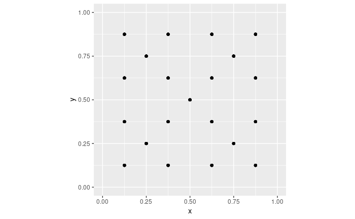

```r
ggplot(data.frame(x = anchors[ ,1], y = anchors[ , 2]), aes(x, y)) +
  geom_point() +
  coord_cartesian(xlim = c(0,1), ylim = c(0,1)) +
  theme(aspect.ratio = 1)
```

Of course, even if we aren’t going to train this version, we at least need to see these in action!

```r
example <- imageinfo4ssd[5, ]
name <- (example$name %>% str_split(pattern = ", "))[[1]]
x_left <- (example$xl %>% str_split(pattern = ", "))[[1]]
x_right <- (example$xr %>% str_split(pattern = ", "))[[1]]
y_top <- (example$yt %>% str_split(pattern = ", "))[[1]]
y_bottom <- (example$yb %>% str_split(pattern = ", "))[[1]]


img <- image_read(file.path(img_dir, example$file_name))
img <- image_resize(img, geometry = "224x224!")
img <- image_draw(img)

for (i in 1:144) {
  rect(
    anchor_corners[i, 1] * 224,
    anchor_corners[i, 4] * 224,
    anchor_corners[i, 3] * 224,
    anchor_corners[i, 2] * 224,
    border = "cyan",
    lwd = 1,
    lty = 1
  )
}

for (i in 145:180) {
  rect(
    anchor_corners[i, 1] * 224,
    anchor_corners[i, 4] * 224,
    anchor_corners[i, 3] * 224,
    anchor_corners[i, 2] * 224,
    border = "violet",
    lwd = 2,
    lty = 1
  )
}

for (i in 181:nrow(anchor_corners)) {
  rect(
    anchor_corners[i, 1] * 224,
    anchor_corners[i, 4] * 224,
    anchor_corners[i, 3] * 224,
    anchor_corners[i, 2] * 224,
    border = "yellow",
    lwd = 3,
    lty = 1
  )
}
dev.off()
```

```r
print(img)
```

[output not shown]

| format | width | height | colorspace | matte | filesize | density |
| --- | --- | --- | --- | --- | --- | --- |
| JPEG | 224 | 224 | sRGB | TRUE | 0 | 72x72 |

```r
NA
```

How would a model look that could deal with these?

# Model

Again, we’d start from a feature detector …

```r
feature_extractor <- application_resnet50(
  include_top = FALSE,
  input_shape = c(224, 224, 3)
)
```

… and attach some custom conv layers.

```r
input <- feature_extractor$input

common <- feature_extractor$output %>%
  layer_conv_2d(
    filters = 256,
    kernel_size = 3,
    padding = "same",
    activation = "relu",
    name = "head_conv1_1"
  ) %>%
  layer_batch_normalization() %>%
  layer_conv_2d(
    filters = 256,
    kernel_size = 3,
    padding = "same",
    activation = "relu",
    name = "head_conv1_2"
  ) %>%
  layer_batch_normalization() %>%
  layer_conv_2d(
    filters = 256,
    kernel_size = 3,
    padding = "same",
    activation = "relu",
    name = "head_conv1_3"
  ) %>%
  layer_batch_normalization()
```

Then, things get different. We want to attach detectors (= output layers) to different stages in a pipeline of successive downsamplings. If that doesn’t call for the Keras functional API…

Here’s the downsizing pipeline.

```r
 downscale_4x4 <- common %>%
  layer_conv_2d(
    filters = 256,
    kernel_size = 3,
    strides = 2,
    padding = "same",
    activation = "relu",
    name = "downscale_4x4"
  ) %>%
  layer_batch_normalization()

downscale_4x4
```

```
Tensor("batch_normalization_4/cond/Merge:0", shape=(?, 4, 4, 256), dtype=float32)
```

```r
downscale_2x2 <- downscale_4x4 %>%
  layer_conv_2d(
    filters = 256,
    kernel_size = 3,
    strides = 2,
    padding = "same",
    activation = "relu",
    name = "downscale_2x2"
  ) %>%
  layer_batch_normalization()

downscale_2x2
```

```
Tensor("batch_normalization_5/cond/Merge:0", shape=(?, 2, 2, 256), dtype=float32)
```

```r
downscale_1x1 <- downscale_2x2 %>%
  layer_conv_2d(
    filters = 256,
    kernel_size = 3,
    strides = 2,
    padding = "same",
    activation = "relu",
    name = "downscale_1x1"
  ) %>%
  layer_batch_normalization()

downscale_1x1
```

```
Tensor("batch_normalization_6/cond/Merge:0", shape=(?, 1, 1, 256), dtype=float32)
```

The bounding box output efinitions get a little messier than before, as each output has to take into account its relative anchor box coordinates.

```r
create_bbox_output <- function(prev_layer, anchor_start, anchor_stop, suffix) {
  output <- layer_conv_2d(
    prev_layer,
    filters = 4 * k,
    kernel_size = 3,
    padding = "same",
    name = paste0("bbox_conv_", suffix)
  ) %>%
  layer_reshape(target_shape = c(-1, 4), name = paste0("bbox_flatten_", suffix)) %>%
  layer_activation("tanh") %>%
  layer_lambda(
    f = function(x) {
      activation_centers <-
        (x[, , 1:2] / 2 * matrix(grid_sizes[anchor_start:anchor_stop], ncol = 1)) + k_constant(anchors[anchor_start:anchor_stop, 1:2])
      activation_height_width <-
        (x[, , 3:4] / 2 + 1) * k_constant(anchors[anchor_start:anchor_stop, 3:4])
      activation_corners <-
        k_concatenate(
          list(
            activation_centers - activation_height_width / 2,
            activation_centers + activation_height_width / 2
          )
        )
     activation_corners
    },
    name = paste0("bbox_output_", suffix)
  )
  output
}
```

Here they are: Each one attached to the required stage in the pipeline.

```r
bbox_output_4x4 <- create_bbox_output(downscale_4x4, 1, 144, "4x4")
```

```r
bbox_output_2x2 <- create_bbox_output(downscale_2x2, 145, 180, "2x2")
```

```r
bbox_output_1x1 <- create_bbox_output(downscale_1x1, 181, 189, "1x1")
```

The same principle applies to the class outputs.

```r
create_class_output <- function(prev_layer, suffix) {
  output <-
  layer_conv_2d(
    prev_layer,
    filters = 21 * k,
    kernel_size = 3,
    padding = "same",
    name = paste0("class_conv_", suffix)
  ) %>%
  layer_reshape(target_shape = c(-1, 21), name = paste0("class_output_", suffix))
  output
}
```

```r
class_output_4x4 <- create_class_output(downscale_4x4, "4x4")
```

```r
class_output_2x2 <- create_class_output(downscale_2x2, "2x2")
```

```r
class_output_1x1 <- create_class_output(downscale_1x1, "1x1")
```

```r
model <- keras_model(
  inputs = input,
  outputs = list(
    bbox_output_1x1,
    bbox_output_2x2,
    bbox_output_4x4,
    class_output_1x1,
    class_output_2x2,
    class_output_4x4)
)
model
```

```
Model
__________________________________________________________________________________________
Layer (type)                 Output Shape        Param #    Connected to
==========================================================================================
input_1 (InputLayer)         (None, 224, 224, 3) 0
__________________________________________________________________________________________
conv1_pad (ZeroPadding2D)    (None, 230, 230, 3) 0          input_1[0][0]
__________________________________________________________________________________________
conv1 (Conv2D)               (None, 112, 112, 64 9472       conv1_pad[0][0]
__________________________________________________________________________________________
bn_conv1 (BatchNormalization (None, 112, 112, 64 256        conv1[0][0]
__________________________________________________________________________________________
activation_1 (Activation)    (None, 112, 112, 64 0          bn_conv1[0][0]
__________________________________________________________________________________________
max_pooling2d_1 (MaxPooling2 (None, 55, 55, 64)  0          activation_1[0][0]
__________________________________________________________________________________________
res2a_branch2a (Conv2D)      (None, 55, 55, 64)  4160       max_pooling2d_1[0][0]
__________________________________________________________________________________________
bn2a_branch2a (BatchNormaliz (None, 55, 55, 64)  256        res2a_branch2a[0][0]
__________________________________________________________________________________________
activation_2 (Activation)    (None, 55, 55, 64)  0          bn2a_branch2a[0][0]
__________________________________________________________________________________________
res2a_branch2b (Conv2D)      (None, 55, 55, 64)  36928      activation_2[0][0]
__________________________________________________________________________________________
bn2a_branch2b (BatchNormaliz (None, 55, 55, 64)  256        res2a_branch2b[0][0]
__________________________________________________________________________________________
activation_3 (Activation)    (None, 55, 55, 64)  0          bn2a_branch2b[0][0]
__________________________________________________________________________________________
res2a_branch2c (Conv2D)      (None, 55, 55, 256) 16640      activation_3[0][0]
__________________________________________________________________________________________
res2a_branch1 (Conv2D)       (None, 55, 55, 256) 16640      max_pooling2d_1[0][0]
__________________________________________________________________________________________
bn2a_branch2c (BatchNormaliz (None, 55, 55, 256) 1024       res2a_branch2c[0][0]
__________________________________________________________________________________________
bn2a_branch1 (BatchNormaliza (None, 55, 55, 256) 1024       res2a_branch1[0][0]
__________________________________________________________________________________________
add_1 (Add)                  (None, 55, 55, 256) 0          bn2a_branch2c[0][0]
                                                            bn2a_branch1[0][0]
__________________________________________________________________________________________
activation_4 (Activation)    (None, 55, 55, 256) 0          add_1[0][0]
```

[output cut: 377 more lines]

```
__________________________________________________________________________________________
bbox_output_2x2 (Lambda)     (None, 36, 4)       0          activation_51[0][0]
__________________________________________________________________________________________
bbox_output_4x4 (Lambda)     (None, 144, 4)      0          activation_50[0][0]
__________________________________________________________________________________________
class_output_1x1 (Reshape)   (None, 9, 21)       0          class_conv_1x1[0][0]
__________________________________________________________________________________________
class_output_2x2 (Reshape)   (None, 36, 21)      0          class_conv_2x2[0][0]
__________________________________________________________________________________________
class_output_4x4 (Reshape)   (None, 144, 21)     0          class_conv_4x4[0][0]
==========================================================================================
Total params: 32,818,979
Trainable params: 32,762,787
Non-trainable params: 56,192
__________________________________________________________________________________________
```